# Model Structure

Alex Benecke

August 21, 2018

```r
eff3 <- read_csv_fn( "data/raw-data/CPUE3.csv", proj, na.strings = c(NA, "")) %>%
  mutate(year = factor(year),
         #pres = factor(pres),
         month = ordered(month,
                         levels = c("Jul", "Aug", "Sep", "Oct", "Nov") )
         )


str(eff3)
headtail(eff3)

strat1_Adult <- load_data(data = eff3[eff3$maturity == "A",], strata = 1)
strat2_Adult <- load_data(data = eff3[eff3$maturity == "A",], strata = 2)

strat1_Juvenile <- load_data(data = eff3[eff3$maturity == "J",], strata = 1)
strat2_Juvenile <- load_data(data = eff3[eff3$maturity == "J",], strata = 2)
```

I want to test various expinential family distributions to find out which one is the best. I think I want binomial with logit link for strata 1 However, I have seen a wide range of distributions used for strata 2 including Tweed with identity link, and negative binomial with log link vs the gamma with a log link I’ve been using.

Next I want to find out if using a mean centered or standardized response variable is better than the un altered response.

Finnaly, what if any transformations of explanatory variables are preferable.

## Finding the best Theoretical distribution for my data

see https://stats.stackexchange.com/questions/132652/how-to-determine-which-distribution-fits-my-data-best

```r
library(fitdistrplus)
library(logspline)
```

```r
### CPUE
cpe <- eff3$CPUE

cpe.bn <- strat2_Adult$Female$blacknose$CPUE
cpe.bt <- strat2_Adult$Female$blacktip$CPUE
cpe.bu <- strat2_Adult$Female$bull$CPUE
cpe.sb <- strat2_Adult$Female$sandbar$CPUE
cpe.sn <- strat2_Adult$Female$sharpnose$CPUE
cpe.sp <- strat2_Adult$Female$spinner$CPUE
cpe.ti <- strat2_Adult$Female$tiger$CPUE



str(cpe)
```

```
##  num [1:140287] 0.923 0 0 0 0 ...
```

```r
### presence absence
pa <- eff3$pres
str(pa)
```

```
##  int [1:140287] 1 0 0 0 0 0 0 0 0 0 ...
```

### PA dist

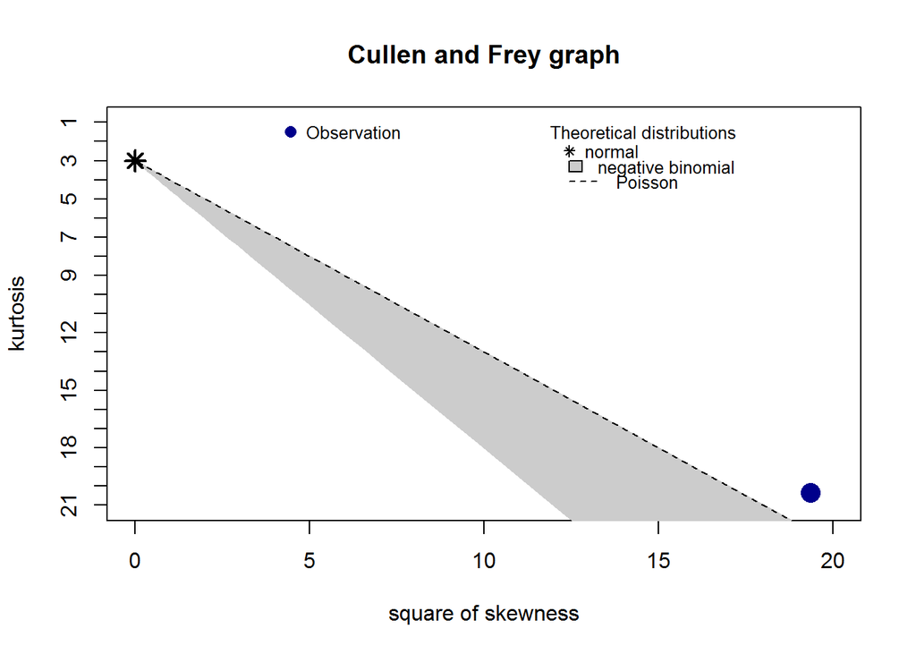

```
## summary statistics
## ------
## min:  0   max:  1
## median:  0
## mean:  0.0448224
## estimated sd:  0.2069146
## estimated skewness:  4.399729
## estimated kurtosis:  20.35786
```

```r
descdist(pa, discrete = TRUE)
```

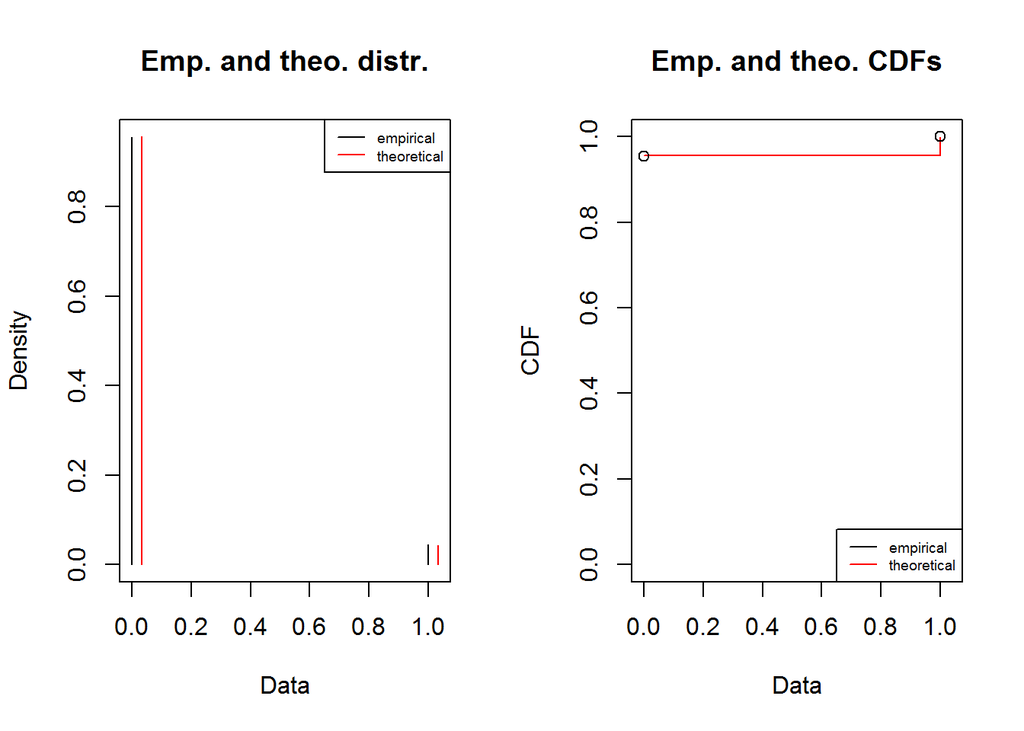

```r
fit.poi <- fitdist(pa,
                     "pois")

fit.nbiom <- fitdist(pa,
                     "nbinom")

#fit.binom <- fitdist(pa,
#                     "binom")

plot(fit.poi)
```

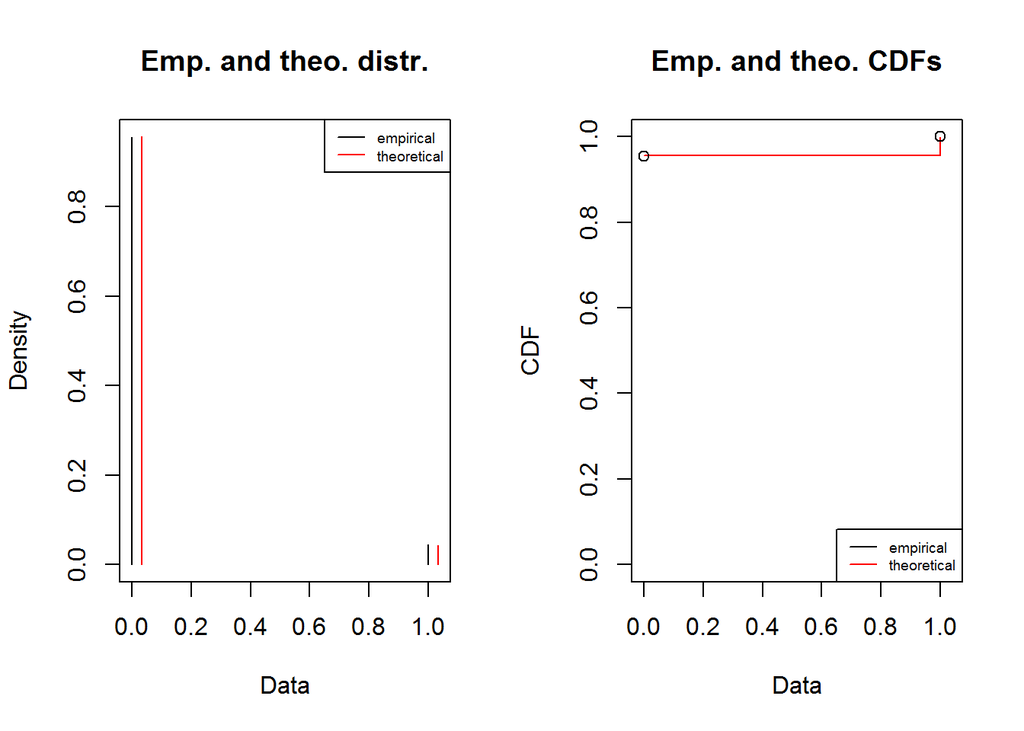

```r
plot(fit.nbiom)
```

```r
summary(fit.poi)
```

```
## Fitting of the distribution ' pois ' by maximum likelihood
## Parameters :
##         estimate   Std. Error
## lambda 0.0448224 0.0005649662
## Loglikelihood:  -25812.54   AIC:  51627.07   BIC:  51636.93
```

```r
summary(fit.nbiom)
```

```
## Fitting of the distribution ' nbinom ' by maximum likelihood
## Parameters :
##         estimate Std. Error
## size 4.04337e+05         NA
## mu   4.48249e-02         NA
## Loglikelihood:  -25812.54   AIC:  51629.08   BIC:  51648.78
## Correlation matrix:
## [1] NA
```

### CPUE dist

Lets fit A Gamma and weibull (Maybe norrmal) distribution

Possible distributions “norm”, “lnorm”, “pois”, “exp”, “gamma”, “nbinom”, “geom”, “beta”, “unif”, “logis”

#### Combined cpe

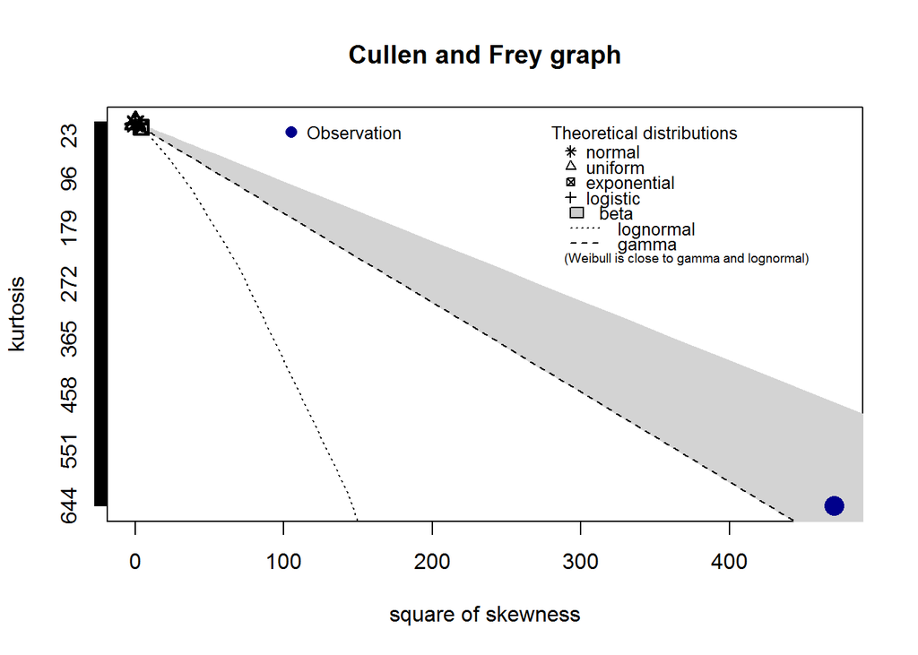

```
## summary statistics
## ------
## min:  0   max:  70
## median:  0
## mean:  0.1432616
## estimated sd:  1.358966
## estimated skewness:  21.68952
## estimated kurtosis:  643.5141
```

```r
### cpe
descdist(cpe, discrete = FALSE)
```

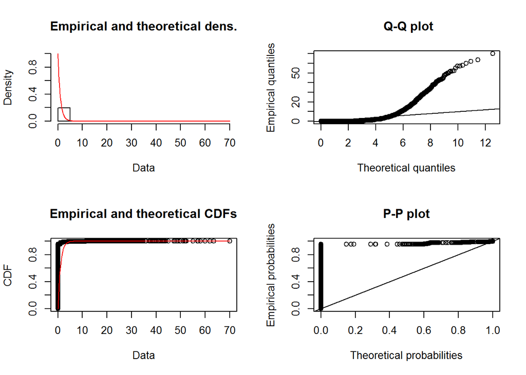

```r
fit.weibull <- fitdist(cpe, "weibull",
                       method = "mle",
                       lower = c(0, 0),
                       start = list(scale = 1, shape = 1))
fit.gamma <- fitdist(cpe, "gamma",
                     method = "mle",
                     lower = c(0, 0),
                     start = list(scale = 1, shape = 1))
fit.norm <- fitdist(cpe, "norm")


plot(fit.weibull)
```

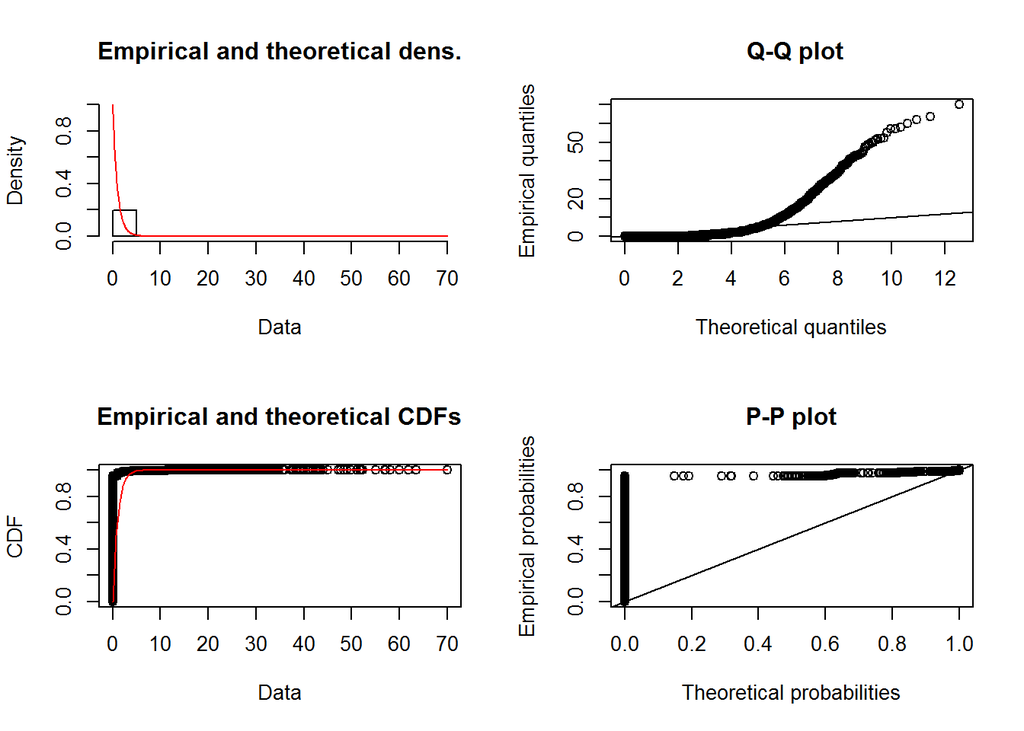

```r
plot(fit.gamma)
```

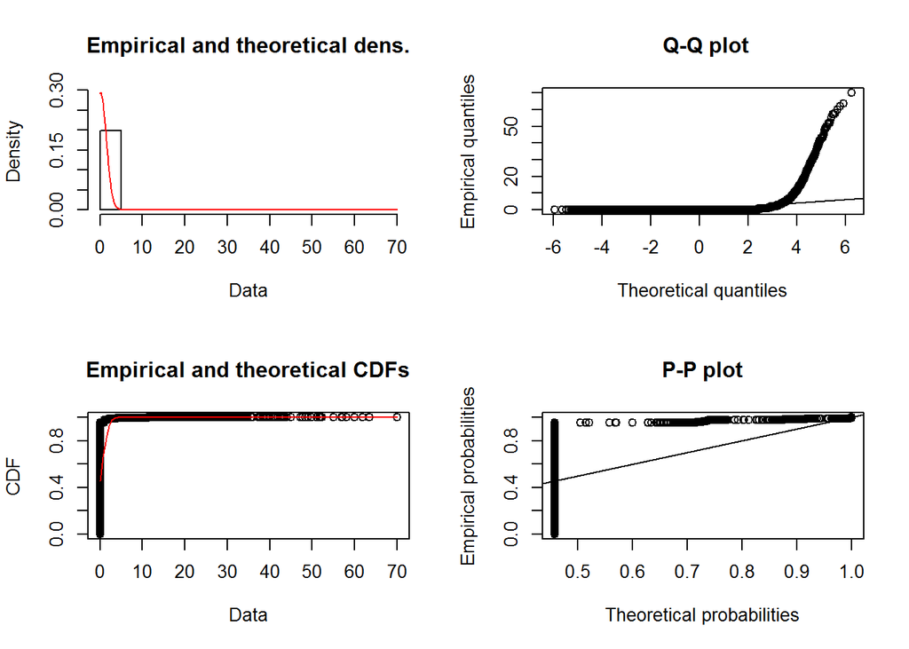

```r
plot(fit.norm)
```

#### Blacknose cpe

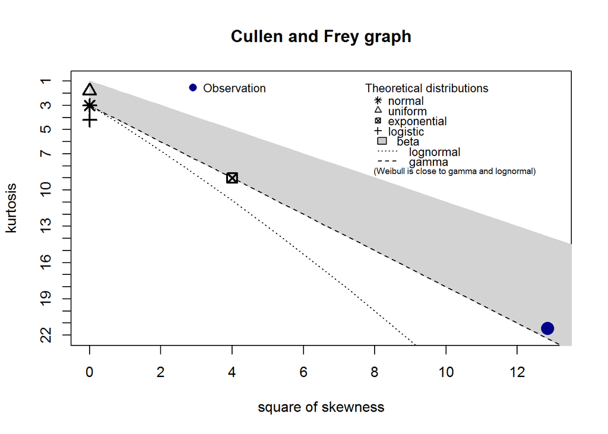

```
## summary statistics
## ------
## min:  0.1604278   max:  15.9375
## median:  1.016949
## mean:  1.885776
## estimated sd:  1.775916
## estimated skewness:  3.585037
## estimated kurtosis:  21.42094
```

```r
### bn
descdist(cpe.bn, discrete = FALSE)
```

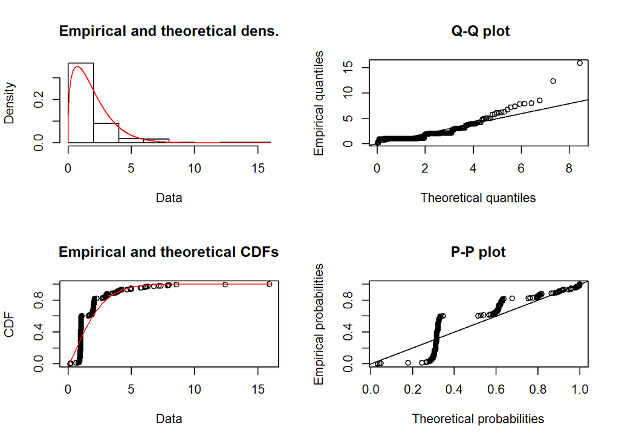

```r
fit.weibull.bn <- fitdist(cpe.bn, "weibull",
                       method = "mle")
fit.gamma.bn <- fitdist(cpe.bn, "gamma",
                     method = "mle")
fit.norm.bn <- fitdist(cpe.bn, "norm")

plot(fit.weibull.bn)
```

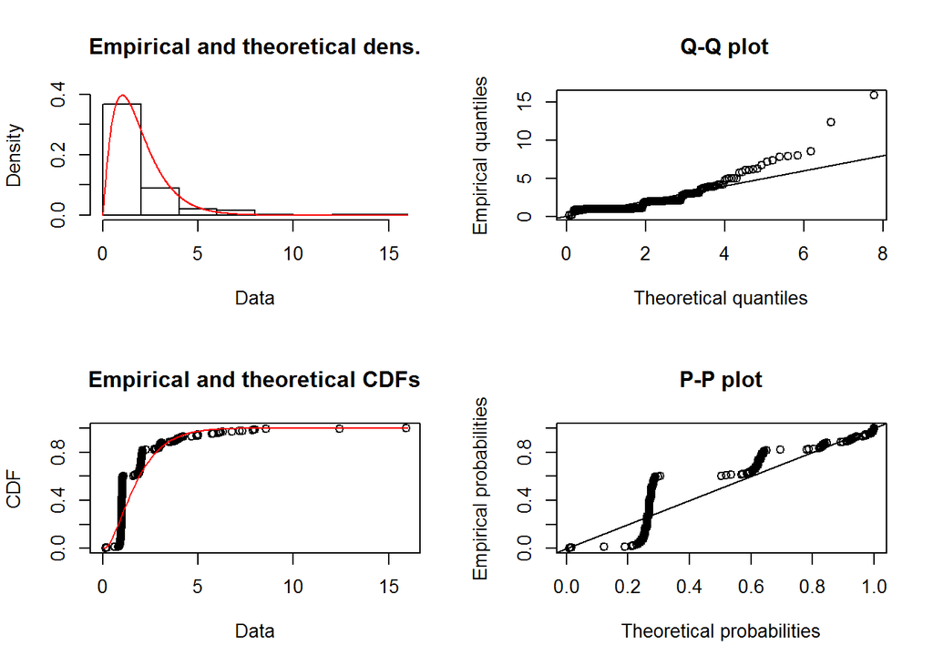

```r
plot(fit.gamma.bn)
```

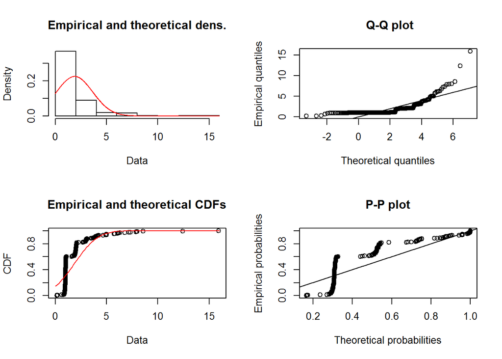

```r
plot(fit.norm.bn)
```

```r
summary(fit.weibull.bn)
```

```
## Fitting of the distribution ' weibull ' by maximum likelihood
## Parameters :
##       estimate Std. Error
## shape 1.324966 0.05128507
## scale 2.079253 0.09664854
## Loglikelihood:  -466.9621   AIC:  937.9242   BIC:  945.3251
## Correlation matrix:
##           shape     scale
## shape 1.0000000 0.3440559
## scale 0.3440559 1.0000000
```

```r
summary(fit.gamma.bn)
```

```
## Fitting of the distribution ' gamma ' by maximum likelihood
## Parameters :
##       estimate Std. Error
## shape 2.201235  0.1681779
## rate  1.167291  0.1001190
## Loglikelihood:  -445.3728   AIC:  894.7456   BIC:  902.1465
## Correlation matrix:
##           shape      rate
## shape 1.0000000 0.8907683
## rate  0.8907683 1.0000000
```

```r
summary(fit.norm.bn)
```

```
## Fitting of the distribution ' norm ' by maximum likelihood
## Parameters :
##      estimate Std. Error
## mean 1.885776 0.10253200
## sd   1.772944 0.07250097
## Loglikelihood:  -595.4824   AIC:  1194.965   BIC:  1202.366
## Correlation matrix:
##      mean sd
## mean    1  0
## sd      0  1
```

Gamma looks like the best here

#### Blacktip cpe

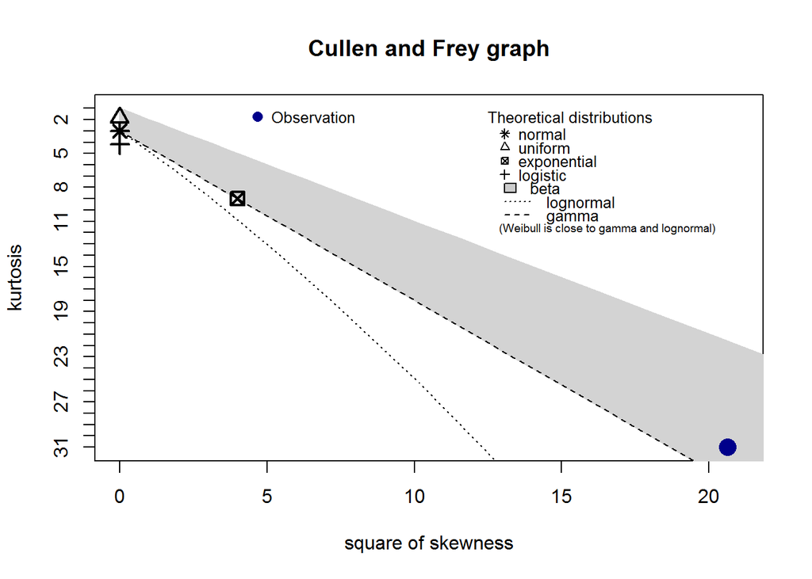

```
## summary statistics
## ------
## min:  0.7594937   max:  18.00847
## median:  1.016949
## mean:  1.860206
## estimated sd:  1.983697
## estimated skewness:  4.542571
## estimated kurtosis:  30.97894
```

```r
descdist(cpe.bt, discrete = FALSE) ### looks like gamma ?or maybe weible?
```

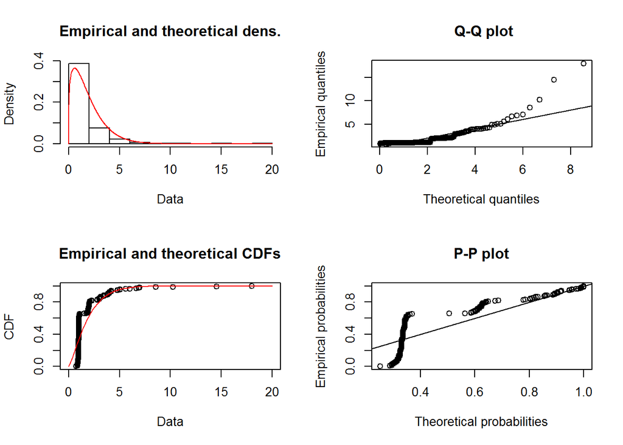

```r
fit.weibull.bt <- fitdist(cpe.bt, "weibull",
                       method = "mle")
fit.gamma.bt <- fitdist(cpe.bt, "gamma",
                     method = "mle")
fit.norm.bt <- fitdist(cpe.bt, "norm")

plot(fit.weibull.bt)
```

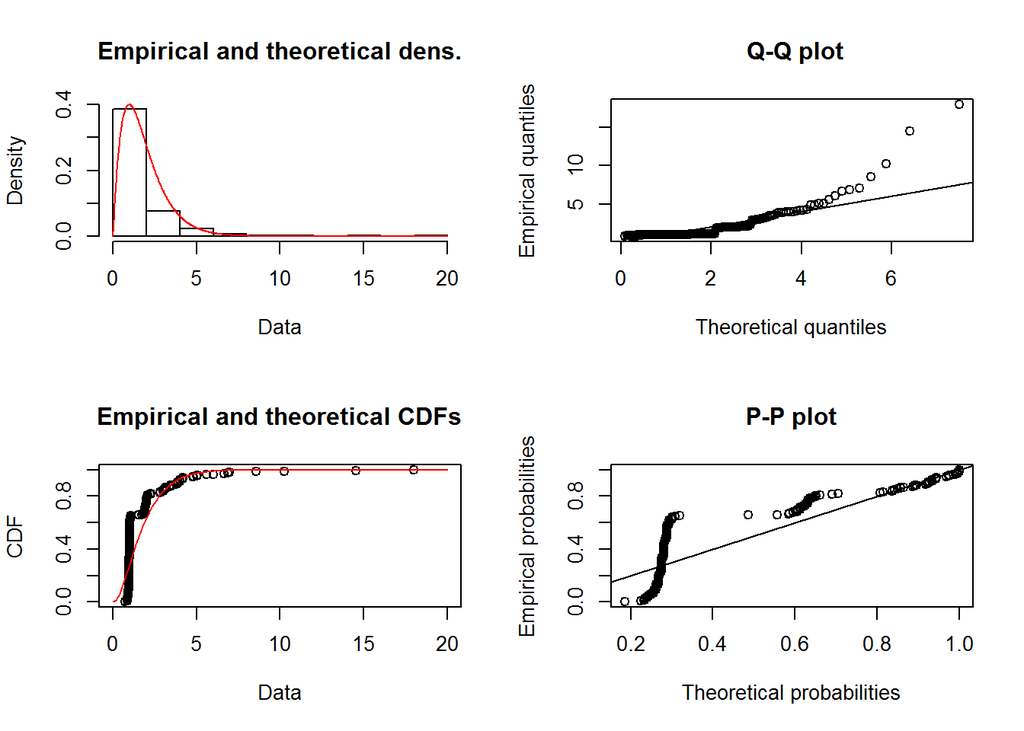

```r
plot(fit.gamma.bt)
```

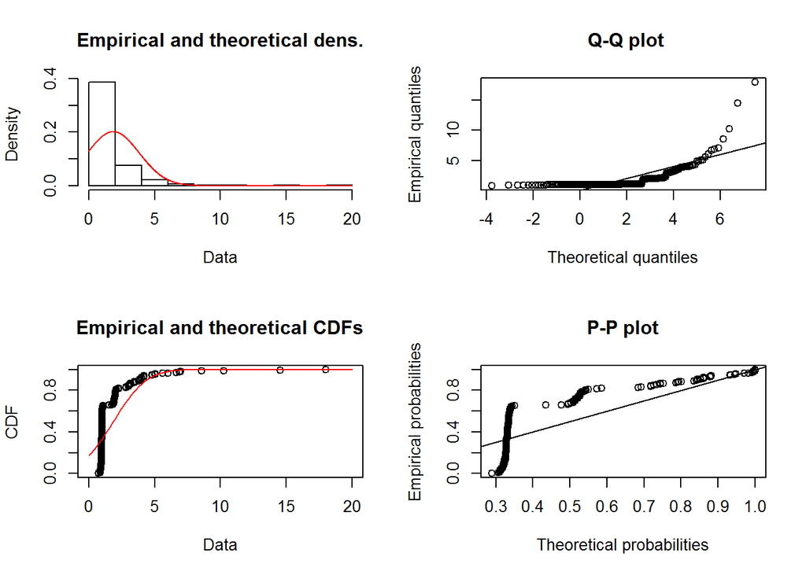

```r
plot(fit.norm.bt)
```

```r
summary(fit.weibull.bt)
```

```
## Fitting of the distribution ' weibull ' by maximum likelihood
## Parameters :
##       estimate Std. Error
## shape 1.258834 0.05462924
## scale 2.033113 0.11530383
## Loglikelihood:  -349.6001   AIC:  703.2001   BIC:  710.0145
## Correlation matrix:
##           shape     scale
## shape 1.0000000 0.3463218
## scale 0.3463218 1.0000000
```

```r
summary(fit.gamma.bt)
```

```
## Fitting of the distribution ' gamma ' by maximum likelihood
## Parameters :
##       estimate Std. Error
## shape 2.128483  0.1879227
## rate  1.144244  0.1138613
## Loglikelihood:  -331.4407   AIC:  666.8813   BIC:  673.6956
## Correlation matrix:
##           shape      rate
## shape 1.0000000 0.8872601
## rate  0.8872601 1.0000000
```

```r
summary(fit.norm.bt)
```

```
## Fitting of the distribution ' norm ' by maximum likelihood
## Parameters :
##      estimate Std. Error
## mean 1.860206 0.13254000
## sd   1.979244 0.09371983
## Loglikelihood:  -468.6688   AIC:  941.3375   BIC:  948.1519
## Correlation matrix:
##      mean sd
## mean    1  0
## sd      0  1
```

Gamma looks like the best here

#### Bull cpe

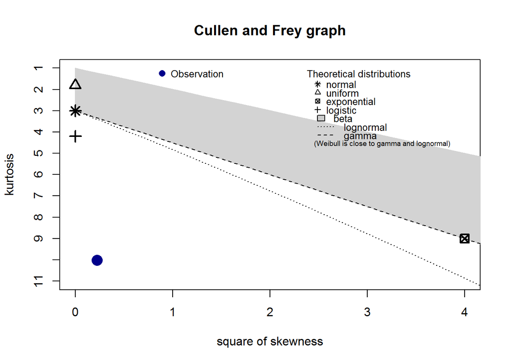

```
## summary statistics
## ------
## min:  0.2141557   max:  1.904762
## median:  1.010101
## mean:  1.015245
## estimated sd:  0.3206074
## estimated skewness:  0.4741786
## estimated kurtosis:  10.02571
```

```r
descdist(cpe.bu, discrete = FALSE) ### maybe lognormal
```

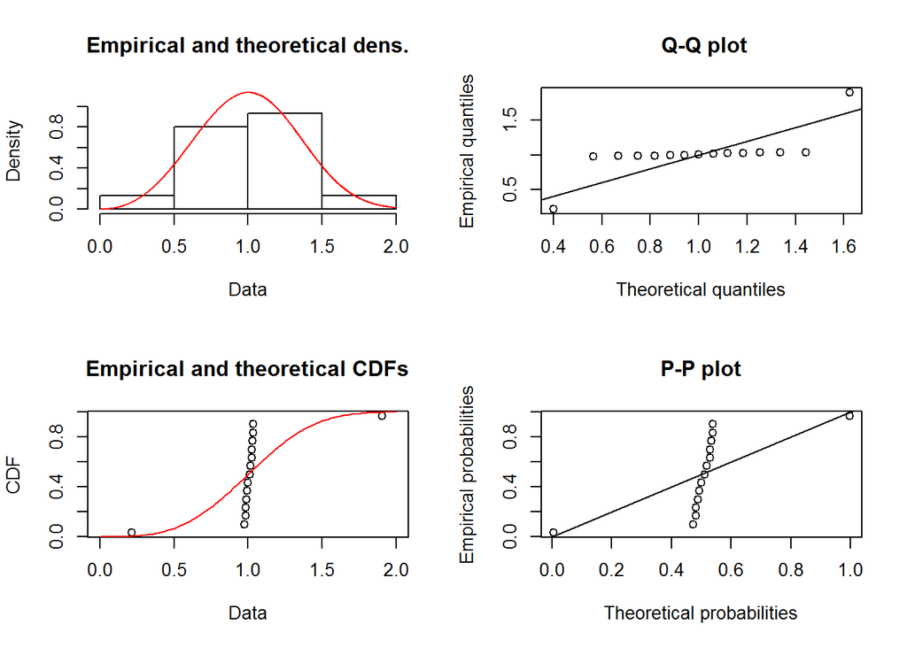

```r
fit.weibull.bu <- fitdist(cpe.bu, "weibull",
                       method = "mle")
fit.lnorm.bu <- fitdist(cpe.bu, "lnorm")

fit.gamma.bu <- fitdist(cpe.bu, "gamma",
                     method = "mle")
fit.norm.bu <- fitdist(cpe.bu, "norm")

plot(fit.weibull.bu)
```

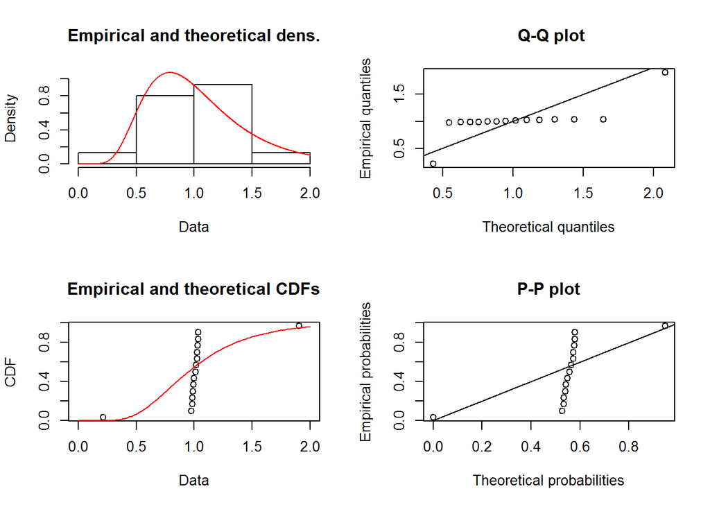

```r
plot(fit.lnorm.bu)
```

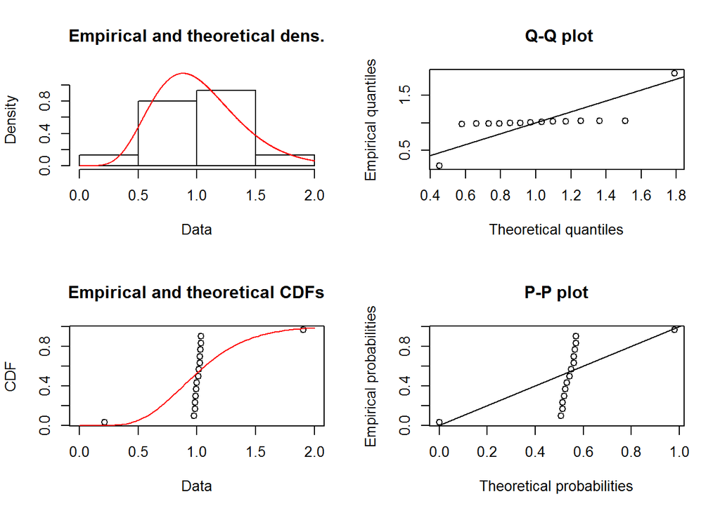

```r
plot(fit.gamma.bu)
```

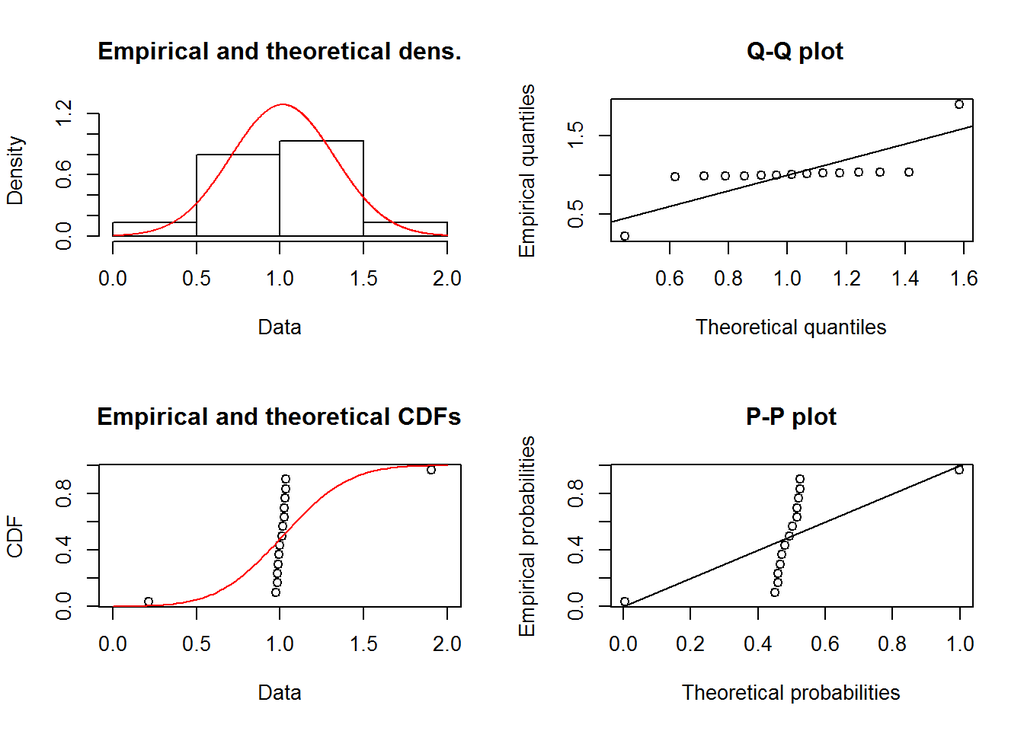

```r
plot(fit.norm.bu)
```

```r
summary(fit.weibull.bu)
```

```
## Fitting of the distribution ' weibull ' by maximum likelihood
## Parameters :
##       estimate Std. Error
## shape 3.283344 0.59372677
## scale 1.118796 0.09240473
## Loglikelihood:  -4.500236   AIC:  13.00047   BIC:  14.41657
## Correlation matrix:
##          shape    scale
## shape 1.000000 0.305806
## scale 0.305806 1.000000
```

```r
summary(fit.lnorm.bu)
```

```
## Fitting of the distribution ' lnorm ' by maximum likelihood
## Parameters :
##            estimate Std. Error
## meanlog -0.05267251 0.11064816
## sdlog    0.42853847 0.07823815
## Loglikelihood:  -7.783369   AIC:  19.56674   BIC:  20.98284
## Correlation matrix:
##              meanlog        sdlog
## meanlog 1.000000e+00 1.922219e-12
## sdlog   1.922219e-12 1.000000e+00
```

```r
summary(fit.gamma.bu)
```

```
## Fitting of the distribution ' gamma ' by maximum likelihood
## Parameters :
##       estimate Std. Error
## shape 7.536776   2.693328
## rate  7.423727   2.743269
## Loglikelihood:  -5.67647   AIC:  15.35294   BIC:  16.76904
## Correlation matrix:
##           shape      rate
## shape 1.0000000 0.9670686
## rate  0.9670686 1.0000000
```

```r
summary(fit.norm.bu)
```

```
## Fitting of the distribution ' norm ' by maximum likelihood
## Parameters :
##       estimate Std. Error
## mean 1.0152450 0.07997355
## sd   0.3097362 0.05654719
## Loglikelihood:  -3.703564   AIC:  11.40713   BIC:  12.82323
## Correlation matrix:
##              mean           sd
## mean 1.000000e+00 7.531108e-13
## sd   7.531108e-13 1.000000e+00
```

Best is normal then weibull, and gamma

#### sandbar cpe

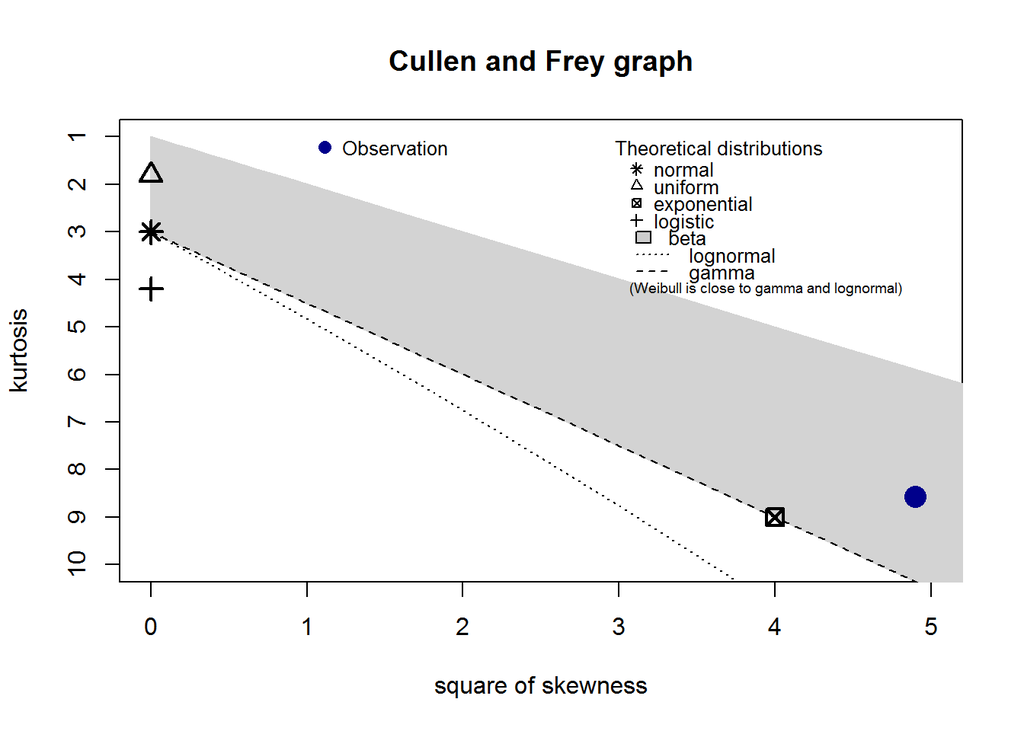

```
## summary statistics
## ------
## min:  0.486697   max:  7.142857
## median:  1.016949
## mean:  1.598977
## estimated sd:  1.119668
## estimated skewness:  2.213648
## estimated kurtosis:  8.570493
```

```r
descdist(cpe.sb, discrete = FALSE)
```

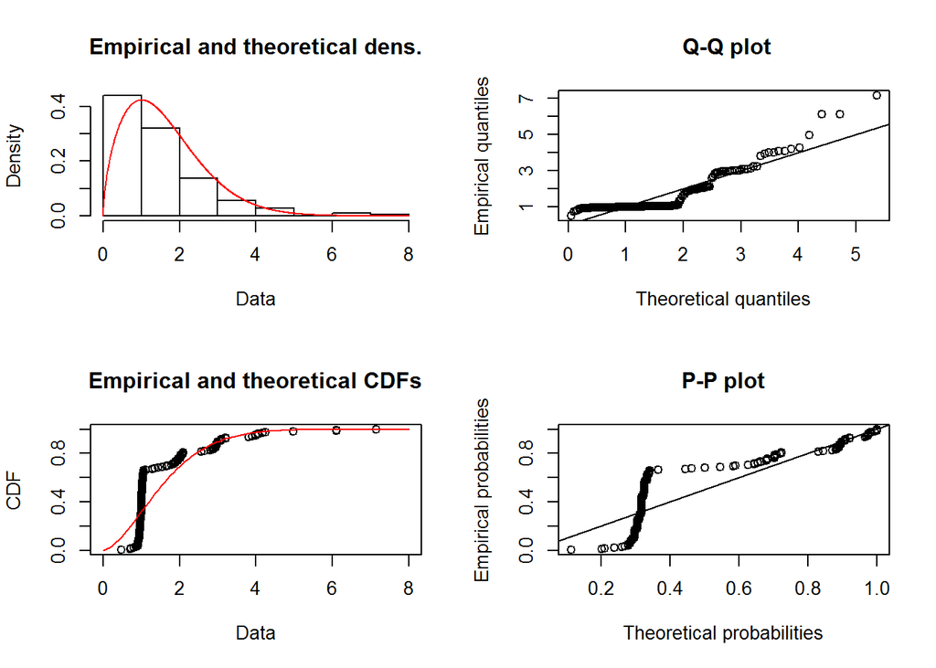

```r
fit.weibull.sb <- fitdist(cpe.sb, "weibull",
                       method = "mle")
fit.gamma.sb <- fitdist(cpe.sb, "gamma",
                     method = "mle")
fit.norm.sb <- fitdist(cpe.sb, "norm")

plot(fit.weibull.sb)
```

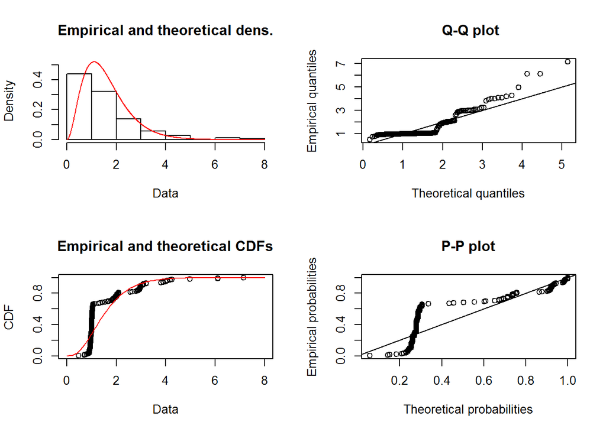

```r
plot(fit.gamma.sb)
```

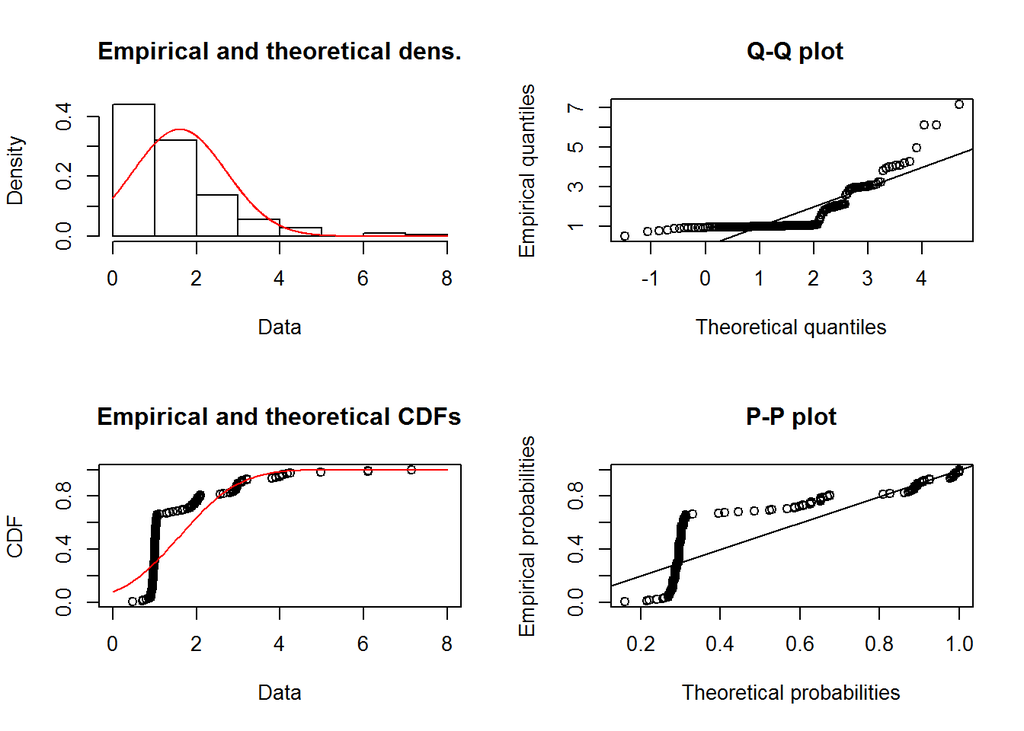

```r
plot(fit.norm.sb)
```

```r
summary(fit.weibull.sb)
```

```
## Fitting of the distribution ' weibull ' by maximum likelihood
## Parameters :
##       estimate Std. Error
## shape 1.626089 0.08486321
## scale 1.808253 0.08959504
## Loglikelihood:  -224.9526   AIC:  453.9052   BIC:  460.2348
## Correlation matrix:
##           shape     scale
## shape 1.0000000 0.3459545
## scale 0.3459545 1.0000000
```

```r
summary(fit.gamma.sb)
```

```
## Fitting of the distribution ' gamma ' by maximum likelihood
## Parameters :
##       estimate Std. Error
## shape 3.218178  0.3277734
## rate  2.012594  0.2218347
## Loglikelihood:  -208.6113   AIC:  421.2227   BIC:  427.5523
## Correlation matrix:
##           shape      rate
## shape 1.0000000 0.9240389
## rate  0.9240389 1.0000000
```

```r
summary(fit.norm.sb)
```

```
## Fitting of the distribution ' norm ' by maximum likelihood
## Parameters :
##      estimate Std. Error
## mean 1.598977 0.08439678
## sd   1.116464 0.05967732
## Loglikelihood:  -267.5935   AIC:  539.1869   BIC:  545.5165
## Correlation matrix:
##             mean          sd
## mean  1.0000e+00 -3.5787e-11
## sd   -3.5787e-11  1.0000e+00
```

Gamma looks like the best here

#### sharpnose cpe

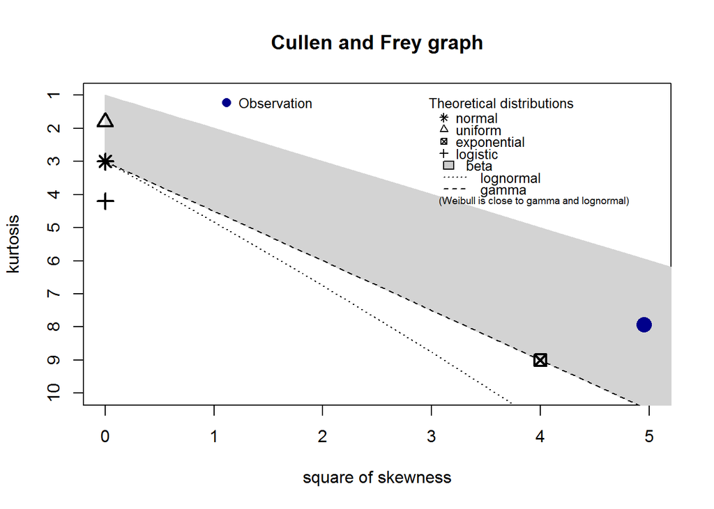

```
## summary statistics
## ------
## min:  0.6122449   max:  70
## median:  3.692308
## mean:  8.961633
## estimated sd:  12.21995
## estimated skewness:  2.225682
## estimated kurtosis:  7.932611
```

```r
descdist(cpe.sn, discrete = FALSE)
```

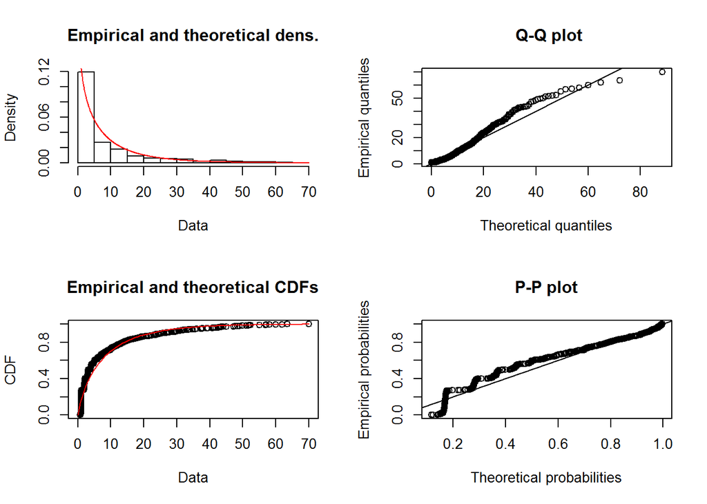

```r
fit.weibull.sn <- fitdist(cpe.sn, "weibull",
                       method = "mle")
fit.gamma.sn <- fitdist(cpe.sn, "gamma",
                     method = "mle")
fit.norm.sn <- fitdist(cpe.sn, "norm")
fit.exp.sn <- fitdist(cpe.sn, "exp")

plot(fit.weibull.sn)
```

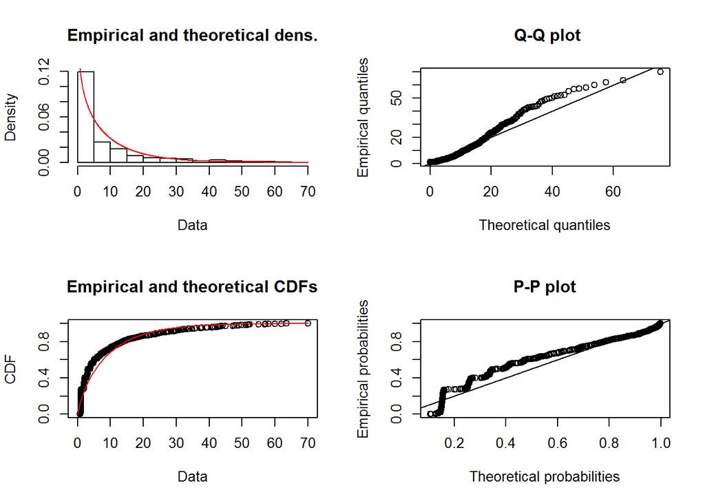

```r
plot(fit.gamma.sn)
```

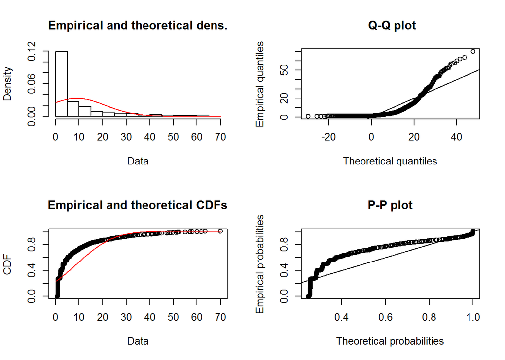

```r
plot(fit.norm.sn)
```

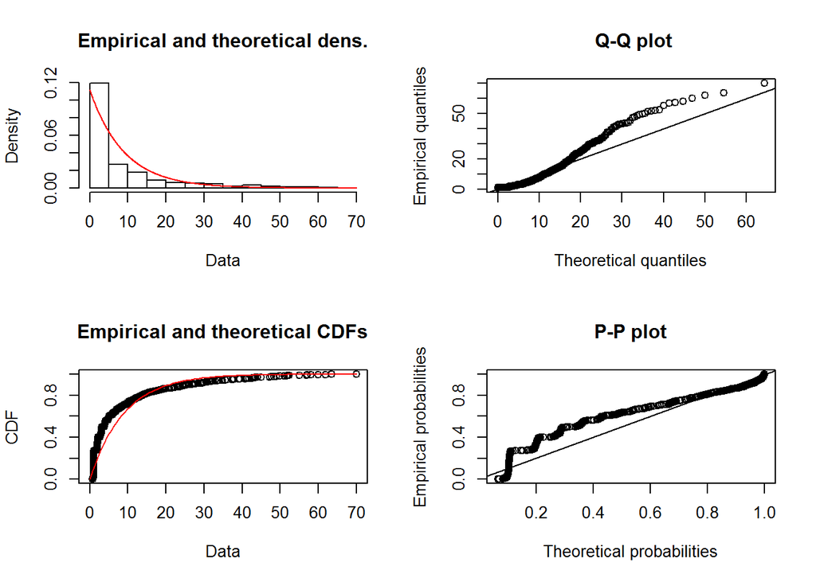

```r
plot(fit.exp.sn)
```

```r
summary(fit.weibull.sn)
```

```
## Fitting of the distribution ' weibull ' by maximum likelihood
## Parameters :
##        estimate Std. Error
## shape 0.8155615 0.02349177
## scale 7.8718507 0.39868733
## Loglikelihood:  -2082.646   AIC:  4169.291   BIC:  4178.279
## Correlation matrix:
##          shape    scale
## shape 1.000000 0.337488
## scale 0.337488 1.000000
```

```r
summary(fit.gamma.sn)
```

```
## Fitting of the distribution ' gamma ' by maximum likelihood
## Parameters :
##        estimate  Std. Error
## shape 0.7808227 0.036969979
## rate  0.0871163 0.005630845
## Loglikelihood:  -2095.916   AIC:  4195.831   BIC:  4204.819
## Correlation matrix:
##           shape      rate
## shape 1.0000000 0.7323643
## rate  0.7323643 1.0000000
```

```r
summary(fit.norm.sn)
```

```
## Fitting of the distribution ' norm ' by maximum likelihood
## Parameters :
##       estimate Std. Error
## mean  8.961633  0.4749411
## sd   12.210699  0.3358341
## Loglikelihood:  -2591.947   AIC:  5187.894   BIC:  5196.881
## Correlation matrix:
##      mean sd
## mean    1  0
## sd      0  1
```

```r
summary(fit.exp.sn)
```

```
## Fitting of the distribution ' exp ' by maximum likelihood
## Parameters :
##       estimate  Std. Error
## rate 0.1115868 0.004339875
## Loglikelihood:  -2110.542   AIC:  4223.083   BIC:  4227.577
```

Weibull looks best here Gamma is close

#### spinner cpe

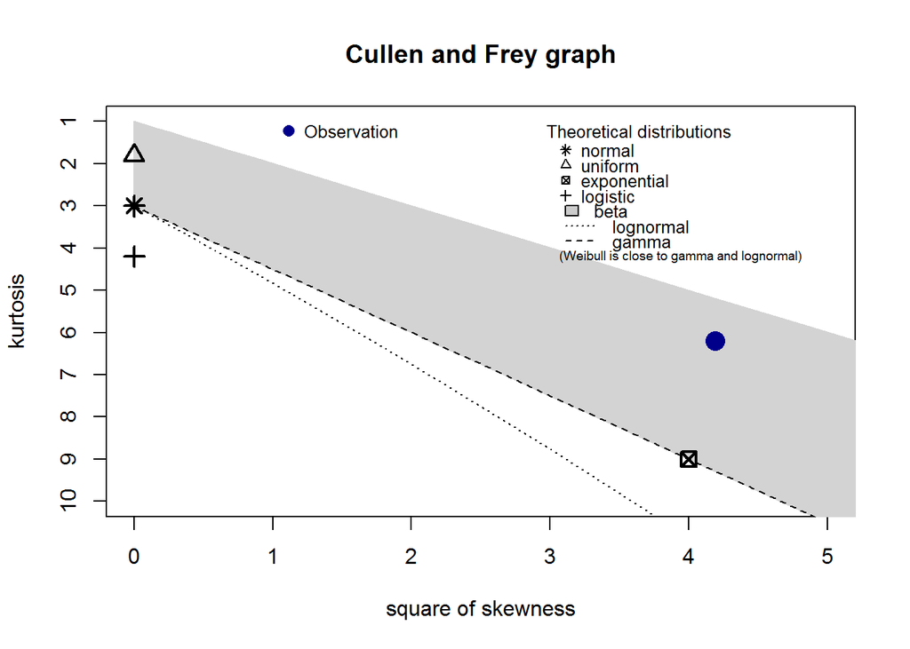

```
## summary statistics
## ------
## min:  0.7228916   max:  1.963672
## median:  0.9805618
## mean:  1.088047
## estimated sd:  0.3742672
## estimated skewness:  2.047359
## estimated kurtosis:  6.195656
```

```r
descdist(cpe.sp, discrete = FALSE)
```

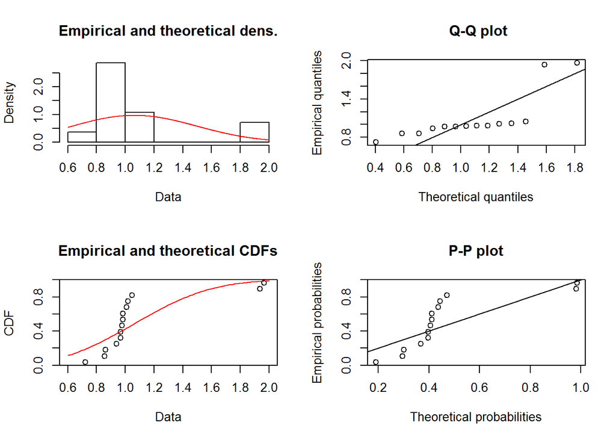

```r
fit.weibull.sp <- fitdist(cpe.sp, "weibull",
                       method = "mle")
fit.gamma.sp <- fitdist(cpe.sp, "gamma",
                     method = "mle")
fit.norm.sp <- fitdist(cpe.sp, "norm")
fit.exp.sp <- fitdist(cpe.sp, "exp")

plot(fit.weibull.sp)
```

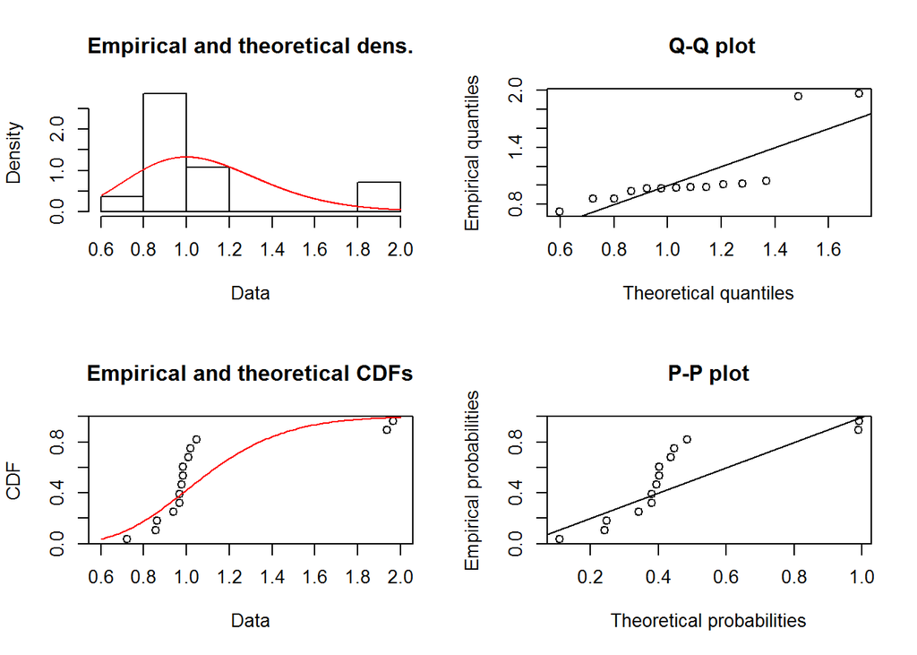

```r
plot(fit.gamma.sp)
```